# Day 3: Hierarchical models — Results

Author

Masatoshi Katabuchi

Published

October 23, 2026

Use this sheet as an offline reference for the lecture and the code-reading activity. The comparison figures are explained before the activity; they are not a second exercise. All summaries use exact updating or supplied fits, with no new Stan inference.

## Lecture reference: mother-tree comparison

| tree | n | suv | observed |
| --- | --- | --- | --- |
| A | 15 | 6 | 0.400 |
| B | 39 | 18 | 0.462 |
| C | 24 | 6 | 0.250 |
| D | 50 | 19 | 0.380 |
| E | 32 | 6 | 0.188 |
| F | 38 | 12 | 0.316 |
| G | 21 | 1 | 0.048 |
| H | 50 | 12 | 0.240 |

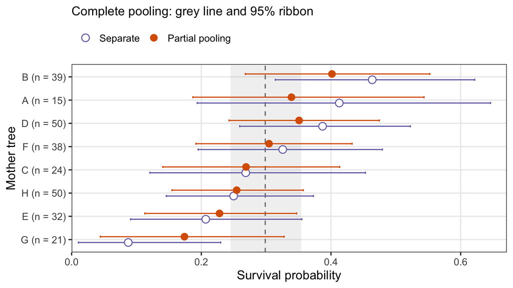

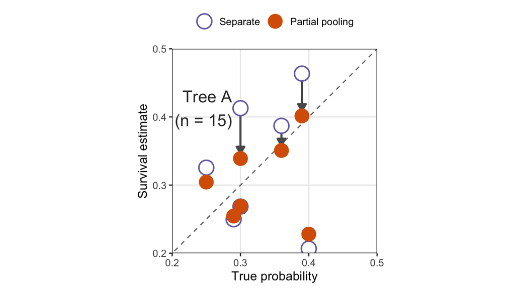

| tree | n | model | mean | lower | upper |
| --- | --- | --- | --- | --- | --- |
| A | 15 | Complete | 0.299 | 0.245 | 0.354 |
| A | 15 | Separate | 0.413 | 0.194 | 0.646 |
| A | 15 | Partial | 0.339 | 0.187 | 0.544 |
| B | 39 | Complete | 0.299 | 0.245 | 0.354 |
| B | 39 | Separate | 0.464 | 0.314 | 0.622 |
| B | 39 | Partial | 0.402 | 0.268 | 0.552 |
| C | 24 | Complete | 0.299 | 0.245 | 0.354 |
| C | 24 | Separate | 0.269 | 0.121 | 0.453 |
| C | 24 | Partial | 0.269 | 0.141 | 0.414 |
| D | 50 | Complete | 0.299 | 0.245 | 0.354 |
| D | 50 | Separate | 0.387 | 0.259 | 0.522 |
| D | 50 | Partial | 0.351 | 0.243 | 0.475 |
| E | 32 | Complete | 0.299 | 0.245 | 0.354 |
| E | 32 | Separate | 0.207 | 0.091 | 0.355 |
| E | 32 | Partial | 0.228 | 0.113 | 0.347 |
| F | 38 | Complete | 0.299 | 0.245 | 0.354 |
| F | 38 | Separate | 0.326 | 0.195 | 0.479 |
| F | 38 | Partial | 0.304 | 0.192 | 0.433 |
| G | 21 | Complete | 0.299 | 0.245 | 0.354 |
| G | 21 | Separate | 0.087 | 0.010 | 0.230 |
| G | 21 | Partial | 0.174 | 0.044 | 0.328 |
| H | 50 | Complete | 0.299 | 0.245 | 0.354 |
| H | 50 | Separate | 0.250 | 0.146 | 0.373 |
| H | 50 | Partial | 0.255 | 0.155 | 0.357 |

Purple open points show separate estimates; orange filled points show partial pooling. The grey line and ribbon show the complete-pooling posterior mean and 95% credible interval; coloured bars are also 95% credible intervals. The line is a comparison reference, not the exact target of hierarchical shrinkage. Rows are ordered by separate posterior means, with seedling counts `n` shown; the two sets of intervals are offset vertically within each tree. The second plot uses the generating probabilities on x and posterior means on y, with a dashed 1:1 reference. Arrows show movement from Separate to Partial pooling. As in the lecture, Tree A is highlighted and both axes run from 0.2 to 0.5. Tree G falls below this window; its estimates remain in the full table. Truth is matched by tree ID.

The complete and separate models use flat Beta(1,1) priors on the probabilities. The partial model uses a shared Normal distribution on the logit scale, with its centre and SD estimated. Prior formulations also differ in this comparison. Movement depends on group information and the inferred differences among trees. It does not guarantee smaller error for every tree.

## Activity reference: Tree A’s partial-pooling probability

Transform the saved logit-intercept draws before summarizing them. These are probability draws, not future survivor counts.

| tree | mean | lower | upper |
| --- | --- | --- | --- |
| A | 0.339 | 0.187 | 0.544 |

The mean and interval match Tree A’s partial-pooling estimate in the lecture. The activity asks readers to find the data, likelihood, shared prior and probability transformation in the supplied code.

## Lecture reference: computational and predictive checks

| max_rhat | min_bulk_ess | min_tail_ess | divergent | max_treedepth | min_ebfmi |
| --- | --- | --- | --- | --- | --- |
| 1 | 779.58 | 1078.92 | 0 | 0 | 0.66 |

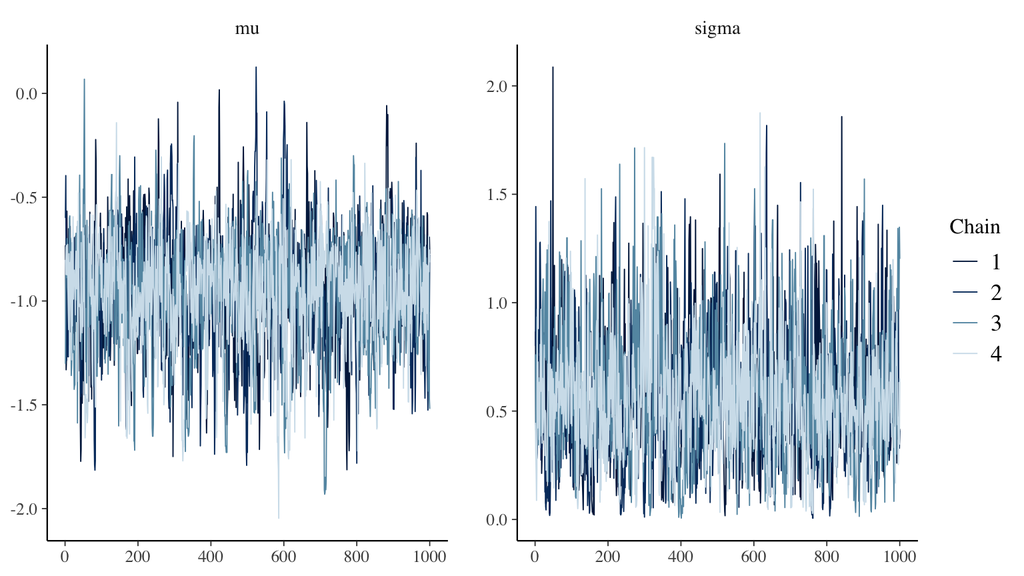

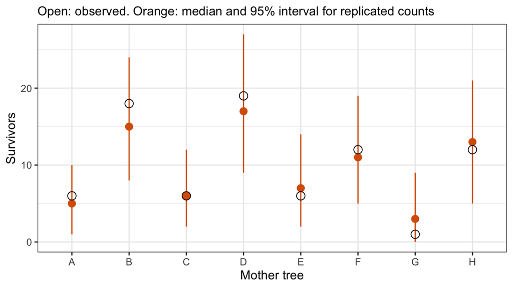

Read sampler diagnostics and traces together. The predictive check generates counts at the observed seedling numbers. Neither these checks nor the presence of a grouping label alone establishes that sharing information is ecologically appropriate.

## Lecture reference: return to regression

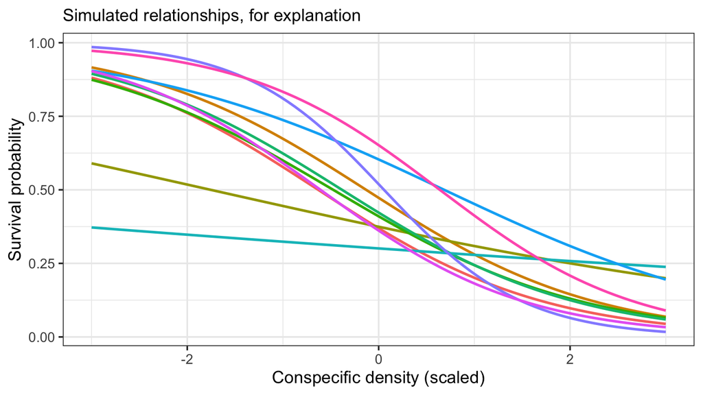

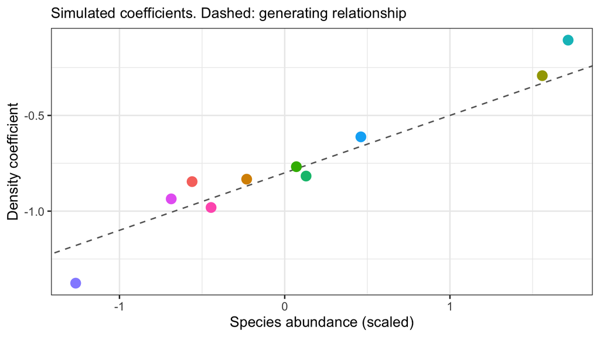

The lecture adds density, then allows intercepts and slopes to vary, then introduces species abundance as a group-level predictor. These curves and coefficients are conceptual simulations, not a fitted extension of the eight mother trees or empirical results from the cited research.

The expanded handout also contains an executed example with a new simulated CNDD data set, three matching saved fits, fitted survival curves and an optional posterior predictive check. It uses wood density as an alternative species-level predictor. Those fitted results are separate from the conceptual lecture figures above.

## Optional reference: allometry and wood density

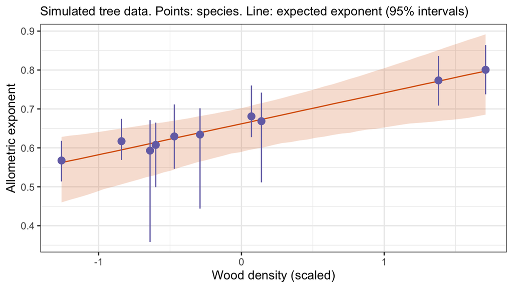

This plot uses a saved fit to simulated allometry data. The observation model changes to Normal log height; information sharing among coefficients is the common structure. It is outside the main activity.